# Quiz 1 Assignment 1

Wilmer Uruchi Ticona

11/2/2018

Including libraries:

```r
library(RcmdrMisc)
```

```r
library(ggplot2)
library(dplyr)
```

After generating a random distribution of 200 values using Blum Blum Shub Algorith, I import this data into R:

```r
v2 = readRDS("BBSRandom.rds")
```

Now, lets generate 200 random number using r studio random generator:

```r
v1=runif(200)
summary(v1)
```

```
##     Min.  1st Qu.   Median     Mean  3rd Qu.     Max.
## 0.001481 0.301100 0.576900 0.545400 0.801700 0.992000
```

```r
summary(v2)
```

```
##    BaseRandom
##  Min.   :0.003815
##  1st Qu.:0.180035
##  Median :0.441965
##  Mean   :0.454670
##  3rd Qu.:0.720750
##  Max.   :0.995883
```

Now, we follow the instructions to order and categorize this data:

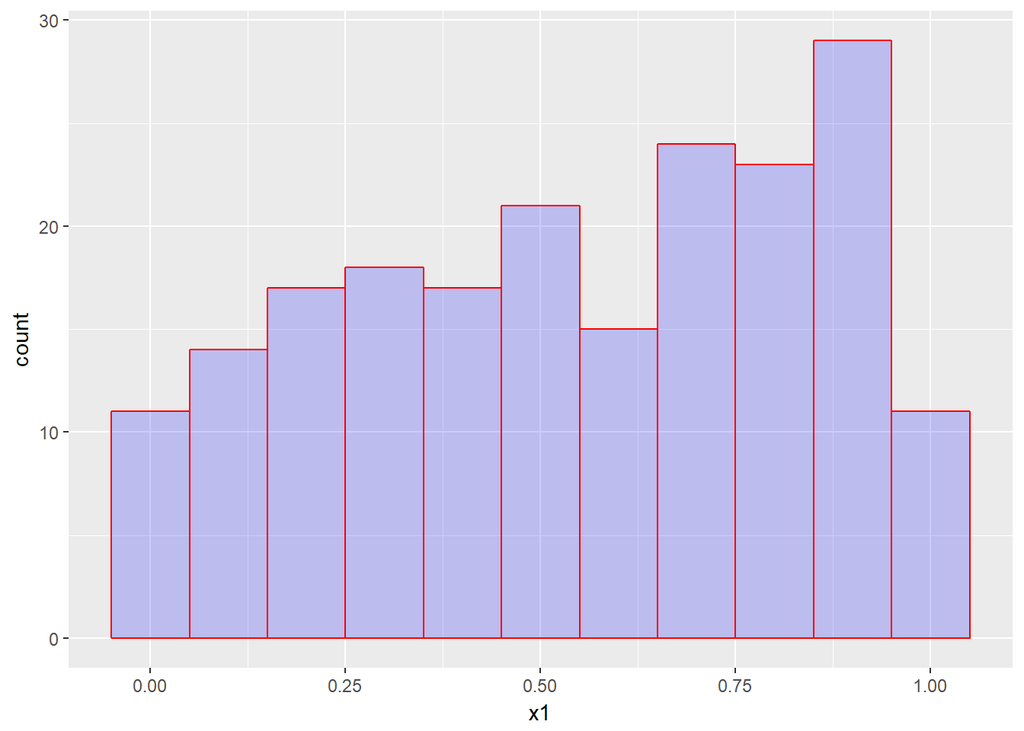

```r
taula_v1=data.frame(x1=v1)
taula_v1_cat=transform(taula_v1, cat = ifelse(x1 < 0.2,"0.2",
                                       ifelse(x1 < 0.4,"0.4",
                                       ifelse(x1 < 0.6,"0.6",
                                       ifelse(x1 < 0.8,"0.8",
                                       ifelse(x1 <1,"1","Inf"))))))
taula_freq_v1 = as.data.frame(with(taula_v1_cat, table(cat)))

ggplot(data = taula_v1_cat, aes(x = x1)) +
  geom_histogram(binwidth = 0.1,fill=I("blue"),
      col=I("red"),alpha=I(.2))
```

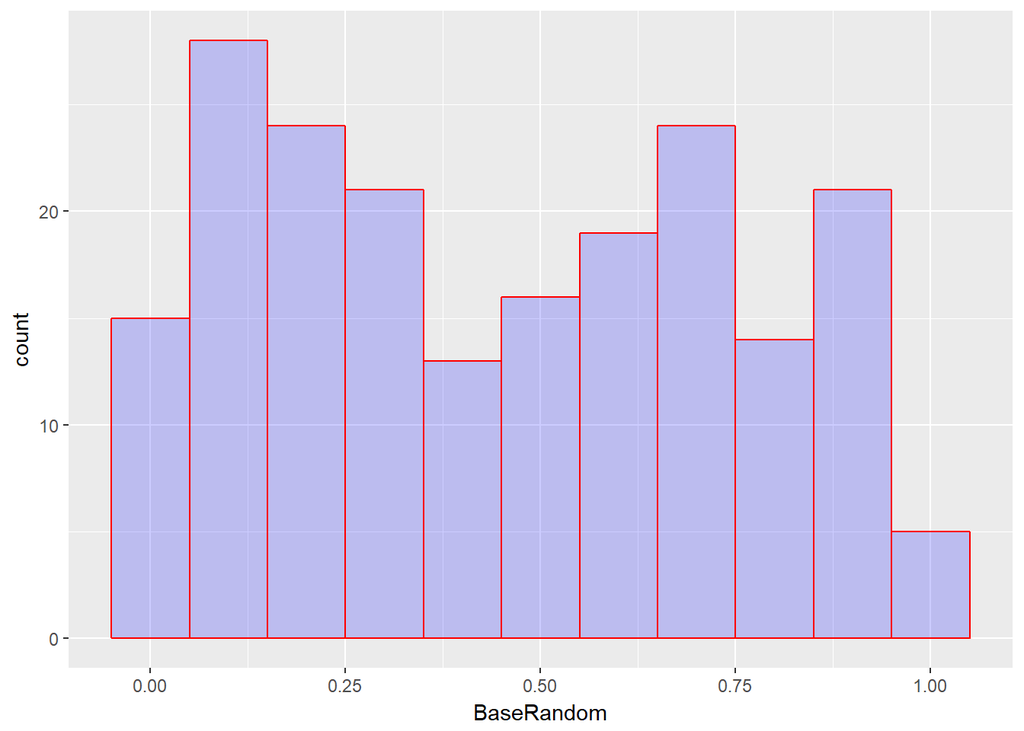

```r
taula_v2=data.frame(x1=v2)
taula_v2_cat=transform(taula_v2, cat = ifelse(BaseRandom < 0.2,"0.2",
                                       ifelse(BaseRandom < 0.4,"0.4",
                                       ifelse(BaseRandom < 0.6,"0.6",
                                       ifelse(BaseRandom < 0.8,"0.8",
                                       ifelse(BaseRandom <1,"1","Inf"))))))
taula_freq_v2 = as.data.frame(with(taula_v2_cat, table(cat)))


ggplot(data = taula_v2_cat, aes(x = BaseRandom)) +
  geom_histogram(binwidth = 0.1,fill=I("blue"),
      col=I("red"),alpha=I(.2))
```

Now, lets create a table with the occurrences for category on both distributions.

```r
taula_freq <- taula_freq_v1 %>% inner_join(taula_freq_v2, by = "cat")
taula_freq <- taula_freq %>% select(Freq.x, Freq.y)
taula_freq
```

```
##   Freq.x Freq.y
## 1     33     53
## 2     33     42
## 3     38     29
## 4     45     42
## 5     51     34
```

Applying chi square test:

```r
Test=chisq.test(taula_freq, correct=FALSE)
Test
```

```
##
##  Pearson's Chi-squared test
##
## data:  taula_freq
## X-squared = 10.444, df = 4, p-value = 0.03358
```

# # Are you really comparing the quality of the RNG or the RVG?

In this case we are comparing the quality of the RVG with the chi-square test. We are comparing if the random distribution generated in r fits the expected distribution (the result of the chosen random generator).

```r
v3=rnorm(200, mean = 0, sd =1)
summary(v3)
```

```
##     Min.  1st Qu.   Median     Mean  3rd Qu.     Max.
## -2.35700 -0.75730 -0.04732 -0.06174  0.59040  3.38900
```

Categorize the data:

```r
taula_v3=data.frame(x1=v3)
taula_v3_cat=transform(taula_v3, cat = ifelse(x1 < 0.2,"0.2",
                                       ifelse(x1 < 0.4,"0.4",
                                       ifelse(x1 < 0.6,"0.6",
                                       ifelse(x1 < 0.8,"0.8",
                                       ifelse(x1 < 1,"1", "Inf"))))))
taula_freq_v3 = as.data.frame(with(taula_v3_cat, table(cat)))
taula_freq_v3 <- taula_freq_v3 %>%
                  filter(cat != "Inf")
taula_freq_v3
```

```
##   cat Freq
## 1 0.2  123
## 2 0.4   12
## 3 0.6   16
## 4 0.8    9
## 5   1    9
```

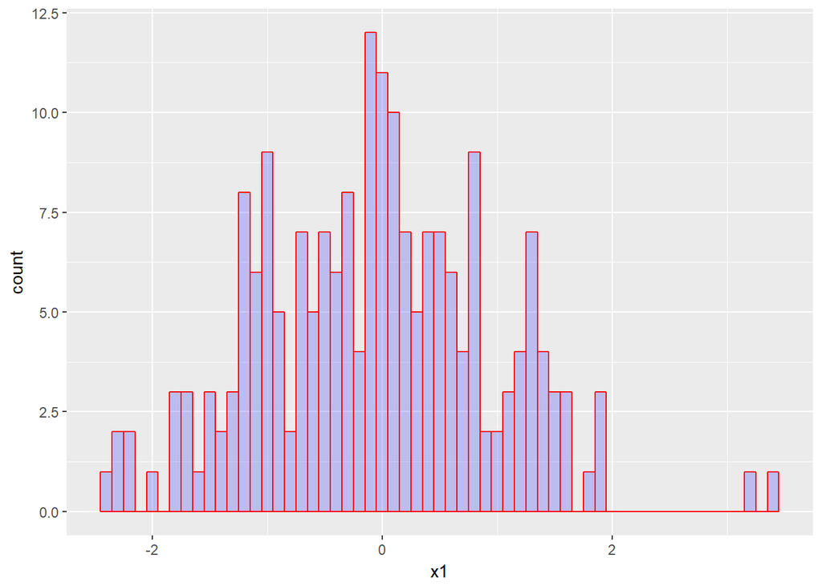

```r
ggplot(data = taula_v3_cat, aes(x = x1)) +
  geom_histogram(binwidth = 0.1,fill=I("blue"),
      col=I("red"),alpha=I(.2))
```

Now, lets create a table with the occurrences for category on both distributions.

```r
taula_freqNorm <- taula_freq_v3 %>% inner_join(taula_freq_v2, by = "cat")
taula_freqNorm <- taula_freqNorm %>% select(Freq.x, Freq.y)
taula_freqNorm
```

```
##   Freq.x Freq.y
## 1    123     53
## 2     12     42
## 3     16     29
## 4      9     42
## 5      9     34
```

Applying chi square test:

```r
Test=chisq.test(taula_freqNorm, correct=FALSE)
Test
```

```
##
##  Pearson's Chi-squared test
##
## data:  taula_freqNorm
## X-squared = 82.126, df = 4, p-value < 2.2e-16
```

This low p-value < 0.05 tells us to reject the null hypothesis, and state that the random distrubution and the normal distribution are different.